# Análisis Exploratorio de Datos

2026-02-15

# 1 Introducción

Este documento presenta un análisis exploratorio completo del conjunto de datos que abarca información del período 2009-2023.

## 1.1 Carga de Datos

```r
datos <- read.csv("datos_combinados.csv",
                  header = TRUE,
                  stringsAsFactors = FALSE,
                  fileEncoding = "UTF-8")
```

**Dataset cargado exitosamente** ✓

# 2 Descripción General del Conjunto de Datos

## 2.1 Dimensiones del Conjunto

```r
n_observaciones <- nrow(datos)
n_variables <- ncol(datos)
```

**Resumen del Dataset:**

- **Observaciones:** 41,623 registros
- **Variables:** 33 columnas
- **Período:** 2009-2023

## 2.2 Significado y Tipo de cada Variable

### 2.2.1 Diccionario de Datos

```r
# Diccionario de datos - Significado de cada variable
diccionario_variables <- data.frame(
  Variable = c(
    "DEPREG", "MUPREG", "MESREG", "AÑOREG",
    "DEPOCU", "MUPOCU", "AREAG",
    "SEXO", "DIAOCU", "MESOCU", "AÑOOCU",
    "TIPAR", "CLAPAR", "VIAPAR",
    "SEMGES", "EDADM",
    "DEPREM", "MUPREM", "GRETNM", "ESCIVM",
    "NACIOM", "OCUPAM", "ESCOLAM",
    "PAISREM", "PUEBLOPM", "CIUOMAD", "NACIONM",
    "CAUDEF", "ASISREC", "SITIOOCU",
    "TOHITE", "TOHINM", "TOHIVI"
  ),
  Significado = c(
    "Departamento de registro",
    "Municipio de registro",
    "Mes de registro",
    "Año de registro",
    "Departamento de ocurrencia",
    "Municipio de ocurrencia",
    "Área geográfica (1=Urbana, 2=Rural)",
    "Sexo del fallecido (1=Masculino, 2=Femenino, 9=No especificado)",
    "Día de ocurrencia",
    "Mes de ocurrencia",
    "Año de ocurrencia",
    "Tipo de parto",
    "Clasificación del parto",
    "Vía del parto",
    "Semanas de gestación",
    "Edad de la madre (en años)",
    "Departamento de residencia de la madre",
    "Municipio de residencia de la madre",
    "Grupo étnico de la madre",
    "Estado civil de la madre",
    "Nacionalidad de la madre",
    "Ocupación de la madre",
    "Escolaridad de la madre (años de estudio)",
    "País de residencia de la madre",
    "Pueblo/comunidad indígena de la madre",
    "Ciudad o municipio de residencia de la madre",
    "Nacionalidad de la madre (código)",
    "Causa de defunción (código CIE-10)",
    "Asistencia recibida (1=Sí, 2=No)",
    "Sitio de ocurrencia del parto",
    "Total de hijos tenidos",
    "Total de hijos nacidos muertos",
    "Total de hijos nacidos vivos"
  ),
  stringsAsFactors = FALSE
)

diccionario_variables %>%
  kable(
    caption = "Tabla 1: Diccionario de Datos - Significado de Variables",
    col.names = c("Variable", "Descripción/Significado"),
    align = c('l', 'l')
  ) %>%
  kable_styling(
    bootstrap_options = c("striped", "hover", "condensed"),
    full_width = TRUE,
    position = "center"
  ) %>%
  row_spec(0, bold = TRUE, color = "white", background = "#3498db") %>%
  scroll_box(width = "100%", height = "500px")
```

Tabla 1: Diccionario de Datos - Significado de Variables

| Variable | Descripción/Significado |
| --- | --- |
| DEPREG | Departamento de registro |
| MUPREG | Municipio de registro |
| MESREG | Mes de registro |
| AÑOREG | Año de registro |
| DEPOCU | Departamento de ocurrencia |
| MUPOCU | Municipio de ocurrencia |
| AREAG | Área geográfica (1=Urbana, 2=Rural) |
| SEXO | Sexo del fallecido (1=Masculino, 2=Femenino, 9=No especificado) |
| DIAOCU | Día de ocurrencia |
| MESOCU | Mes de ocurrencia |
| AÑOOCU | Año de ocurrencia |
| TIPAR | Tipo de parto |
| CLAPAR | Clasificación del parto |
| VIAPAR | Vía del parto |
| SEMGES | Semanas de gestación |
| EDADM | Edad de la madre (en años) |
| DEPREM | Departamento de residencia de la madre |
| MUPREM | Municipio de residencia de la madre |
| GRETNM | Grupo étnico de la madre |
| ESCIVM | Estado civil de la madre |
| NACIOM | Nacionalidad de la madre |
| OCUPAM | Ocupación de la madre |
| ESCOLAM | Escolaridad de la madre (años de estudio) |
| PAISREM | País de residencia de la madre |
| PUEBLOPM | Pueblo/comunidad indígena de la madre |
| CIUOMAD | Ciudad o municipio de residencia de la madre |
| NACIONM | Nacionalidad de la madre (código) |
| CAUDEF | Causa de defunción (código CIE-10) |
| ASISREC | Asistencia recibida (1=Sí, 2=No) |
| SITIOOCU | Sitio de ocurrencia del parto |
| TOHITE | Total de hijos tenidos |
| TOHINM | Total de hijos nacidos muertos |
| TOHIVI | Total de hijos nacidos vivos |

### 2.2.2 Clasificación Estadística de Variables

```r
# Función para clasificar variables
clasificar_variable <- function(variable, nombre_var) {
  if(is.character(variable)) {
    return("Cualitativa - Nominal")
  }

  if(is.numeric(variable)) {
    valores_unicos <- length(unique(na.omit(variable)))
    total_valores <- length(na.omit(variable))
    ratio <- valores_unicos / total_valores

    variables_discretas <- c("SEXO", "DEPREG", "MUPREG", "MESREG", "DEPOCU",
                             "MUPOCU", "AREAG", "TIPAR", "CLAPAR", "DEPREM",
                             "MUPREM", "GRETNM", "ESCIVM", "NACIOM", "OCUPAM",
                             "ASISREC", "SITIOOCU", "TOHITE", "TOHINM", "TOHIVI",
                             "VIAPAR", "ESCOLAM", "PAISREM", "PUEBLOPM", "NACIONM",
                             "DIAOCU", "MESOCU", "AÑOOCU", "AÑOREG")

    variables_continuas <- c("EDADM", "SEMGES")

    if(nombre_var %in% variables_discretas) {
      return("Cuantitativa - Discreta")
    } else if(nombre_var %in% variables_continuas) {
      return("Cuantitativa - Continua")
    } else {
      if(ratio < 0.05 || valores_unicos < 50) {
        return("Cuantitativa - Discreta")
      } else {
        return("Cuantitativa - Continua")
      }
    }
  }
  return("Otro")
}

# Crear tabla de información de variables
info_variables <- data.frame(
  Variable = names(datos),
  Tipo_R = sapply(datos, class),
  Clasificacion = sapply(names(datos), function(nom) {
    clasificar_variable(datos[[nom]], nom)
  }),
  Valores_Unicos = sapply(datos, function(x) length(unique(na.omit(x)))),
  Valores_NA = sapply(datos, function(x) sum(is.na(x))),
  Porcentaje_NA = round(sapply(datos, function(x) sum(is.na(x)) / length(x) * 100), 2)
)

# Mostrar tabla con formato mejorado
info_variables %>%
  kable(
    caption = "Tabla 2: Clasificación y Características de las Variables",
    col.names = c("Variable", "Tipo en R", "Clasificación Estadística",
                  "Valores Únicos", "Valores NA", "% NA"),
    align = c('l', 'c', 'l', 'r', 'r', 'r')
  ) %>%
  kable_styling(
    bootstrap_options = c("striped", "hover", "condensed"),
    full_width = FALSE,
    position = "center"
  ) %>%
  row_spec(0, bold = TRUE, color = "white", background = "#3498db") %>%
  scroll_box(width = "100%", height = "500px")
```

Tabla 2: Clasificación y Características de las Variables

|  | Variable | Tipo en R | Clasificación Estadística | Valores Únicos | Valores NA | % NA |
| --- | --- | --- | --- | --- | --- | --- |
| DEPREG | DEPREG | numeric | Cuantitativa - Discreta | 22 | 0 | 0.00 |
| MUPREG | MUPREG | integer | Cuantitativa - Discreta | 335 | 0 | 0.00 |
| MESREG | MESREG | numeric | Cuantitativa - Discreta | 12 | 0 | 0.00 |
| AÑOREG | AÑOREG | numeric | Cuantitativa - Discreta | 15 | 0 | 0.00 |
| DEPOCU | DEPOCU | numeric | Cuantitativa - Discreta | 22 | 0 | 0.00 |
| MUPOCU | MUPOCU | integer | Cuantitativa - Discreta | 311 | 0 | 0.00 |
| AREAG | AREAG | numeric | Cuantitativa - Discreta | 3 | 12695 | 30.50 |
| SEXO | SEXO | numeric | Cuantitativa - Discreta | 3 | 0 | 0.00 |
| DIAOCU | DIAOCU | numeric | Cuantitativa - Discreta | 31 | 0 | 0.00 |
| MESOCU | MESOCU | numeric | Cuantitativa - Discreta | 12 | 0 | 0.00 |
| AÑOOCU | AÑOOCU | numeric | Cuantitativa - Discreta | 11 | 9737 | 23.39 |
| TIPAR | TIPAR | numeric | Cuantitativa - Discreta | 4 | 0 | 0.00 |
| CLAPAR | CLAPAR | numeric | Cuantitativa - Discreta | 3 | 0 | 0.00 |
| SEMGES | SEMGES | numeric | Cuantitativa - Continua | 67 | 0 | 0.00 |
| EDADM | EDADM | numeric | Cuantitativa - Continua | 47 | 0 | 0.00 |
| DEPREM | DEPREM | numeric | Cuantitativa - Discreta | 25 | 0 | 0.00 |
| MUPREM | MUPREM | integer | Cuantitativa - Discreta | 341 | 0 | 0.00 |
| GRETNM | GRETNM | numeric | Cuantitativa - Discreta | 3 | 28590 | 68.69 |
| ESCIVM | ESCIVM | numeric | Cuantitativa - Discreta | 4 | 0 | 0.00 |
| NACIOM | NACIOM | numeric | Cuantitativa - Discreta | 18 | 22010 | 52.88 |
| OCUPAM | OCUPAM | numeric | Cuantitativa - Discreta | 72 | 28590 | 68.69 |
| CAUDEF | CAUDEF | character | Cualitativa - Nominal | 206 | 0 | 0.00 |
| ASISREC | ASISREC | numeric | Cuantitativa - Discreta | 6 | 0 | 0.00 |
| SITIOOCU | SITIOOCU | numeric | Cuantitativa - Discreta | 9 | 0 | 0.00 |
| TOHITE | TOHITE | numeric | Cuantitativa - Discreta | 21 | 351 | 0.84 |
| TOHINM | TOHINM | numeric | Cuantitativa - Discreta | 17 | 142 | 0.34 |
| TOHIVI | TOHIVI | numeric | Cuantitativa - Discreta | 19 | 258 | 0.62 |
| VIAPAR | VIAPAR | numeric | Cuantitativa - Discreta | 2 | 3233 | 7.77 |
| ESCOLAM | ESCOLAM | numeric | Cuantitativa - Discreta | 7 | 3233 | 7.77 |
| PAISREM | PAISREM | numeric | Cuantitativa - Discreta | 6 | 9876 | 23.73 |
| PUEBLOPM | PUEBLOPM | numeric | Cuantitativa - Discreta | 6 | 13033 | 31.31 |
| CIUOMAD | CIUOMAD | character | Cualitativa - Nominal | 74 | 0 | 0.00 |
| NACIONM | NACIONM | numeric | Cuantitativa - Discreta | 17 | 19613 | 47.12 |

### 2.2.3 Resumen por Tipo de Variable

```r
resumen_tipos <- info_variables %>%
  group_by(Clasificacion) %>%
  summarise(
    Cantidad = n(),
    Porcentaje = round(n() / nrow(info_variables) * 100, 1)
  )

resumen_tipos %>%
  kable(
    caption = "Tabla 3: Distribución de Variables por Tipo",
    col.names = c("Clasificación", "Cantidad", "Porcentaje (%)"),
    align = c('l', 'r', 'r')
  ) %>%
  kable_styling(
    bootstrap_options = c("striped", "hover"),
    full_width = FALSE,
    position = "center"
  ) %>%
  row_spec(0, bold = TRUE, color = "white", background = "#2ecc71")
```

Tabla 3: Distribución de Variables por Tipo

| Clasificación | Cantidad | Porcentaje (%) |
| --- | --- | --- |
| Cualitativa - Nominal | 2 | 6.1 |
| Cuantitativa - Continua | 2 | 6.1 |
| Cuantitativa - Discreta | 29 | 87.9 |

# 3 Exploración de Variables Numéricas

## 3.1 Medidas de Tendencia Central, Distribución y Orden

```r
vars_numericas <- names(datos)[sapply(datos, is.numeric)]

resumen_numericas <- data.frame(
  Variable = character(),
  Media = numeric(),
  Mediana = numeric(),
  Desv_Est = numeric(),
  Min = numeric(),
  Max = numeric(),
  Q1 = numeric(),
  Q3 = numeric(),
  Asimetria = numeric(),
  Curtosis = numeric(),
  stringsAsFactors = FALSE
)

for(var in vars_numericas) {
  datos_var <- datos[[var]][!is.na(datos[[var]])]

  if(length(datos_var) > 0) {
    resumen_numericas <- rbind(resumen_numericas, data.frame(
      Variable = var,
      Media = mean(datos_var),
      Mediana = median(datos_var),
      Desv_Est = sd(datos_var),
      Min = min(datos_var),
      Max = max(datos_var),
      Q1 = quantile(datos_var, 0.25),
      Q3 = quantile(datos_var, 0.75),
      Asimetria = skewness(datos_var),
      Curtosis = kurtosis(datos_var)
    ))
  }
}

resumen_numericas %>%
  mutate(across(where(is.numeric), ~round(., 2))) %>%
  kable(
    caption = "Tabla 4: Estadísticas Descriptivas de Variables Numéricas",
    align = c('l', rep('r', 9))
  ) %>%
  kable_styling(
    bootstrap_options = c("striped", "hover", "condensed"),
    full_width = TRUE,
    font_size = 11
  ) %>%
  row_spec(0, bold = TRUE, color = "white", background = "#e74c3c") %>%
  scroll_box(width = "100%", height = "400px")
```

Tabla 4: Estadísticas Descriptivas de Variables Numéricas

|  | Variable | Media | Mediana | Desv_Est | Min | Max | Q1 | Q3 | Asimetria | Curtosis |
| --- | --- | --- | --- | --- | --- | --- | --- | --- | --- | --- |
| 25% | DEPREG | 8.70 | 9 | 6.14 | 1 | 22 | 2 | 14 | 0.16 | 1.76 |
| 25%1 | MUPREG | 874.42 | 901 | 615.18 | 101 | 2217 | 201 | 1415 | 0.16 | 1.75 |
| 25%2 | MESREG | 6.47 | 7 | 3.46 | 1 | 12 | 3 | 9 | -0.02 | 1.78 |
| 25%3 | AÑOREG | 2015.09 | 2015 | 3.94 | 2009 | 2023 | 2012 | 2018 | 0.13 | 1.87 |
| 25%4 | DEPOCU | 8.70 | 9 | 6.14 | 1 | 22 | 2 | 14 | 0.16 | 1.76 |
| 25%5 | MUPOCU | 874.09 | 901 | 615.00 | 101 | 2215 | 201 | 1415 | 0.16 | 1.75 |
| 25%6 | AREAG | 2.03 | 1 | 2.42 | 1 | 9 | 1 | 2 | 2.45 | 7.23 |
| 25%7 | SEXO | 1.51 | 1 | 0.71 | 1 | 9 | 1 | 2 | 5.32 | 56.57 |
| 25%8 | DIAOCU | 15.64 | 16 | 8.76 | 1 | 31 | 8 | 23 | 0.02 | 1.81 |
| 25%9 | MESOCU | 6.50 | 7 | 3.45 | 1 | 12 | 3 | 9 | -0.02 | 1.79 |
| 25%10 | AÑOOCU | 1812.91 | 2016 | 605.96 | 9 | 2022 | 2011 | 2019 | -2.64 | 7.97 |
| 25%11 | TIPAR | 1.45 | 1 | 1.78 | 1 | 9 | 1 | 1 | 3.97 | 16.92 |
| 25%12 | CLAPAR | 1.64 | 1 | 1.77 | 1 | 9 | 1 | 2 | 3.69 | 15.48 |
| 25%13 | SEMGES | 71.30 | 37 | 168.45 | 1 | 999 | 32 | 40 | 5.25 | 28.96 |
| 25%14 | EDADM | 59.42 | 28 | 162.49 | 10 | 999 | 22 | 35 | 5.54 | 32.10 |
| 25%15 | DEPREM | 38.56 | 10 | 456.63 | 1 | 9999 | 4 | 16 | 21.69 | 473.22 |
| 25%16 | MUPREM | 1802.71 | 1020 | 2704.10 | 101 | 9999 | 409 | 1609 | 2.55 | 7.98 |
| 25%17 | GRETNM | 4.18 | 2 | 3.65 | 1 | 9 | 1 | 9 | 0.54 | 1.34 |
| 25%18 | ESCIVM | 1.99 | 1 | 2.02 | 1 | 9 | 1 | 2 | 2.98 | 10.59 |
| 25%19 | NACIOM | 446.38 | 320 | 1202.85 | 31 | 9999 | 320 | 320 | 7.79 | 61.87 |
| 25%20 | OCUPAM | 9393.85 | 9711 | 1498.07 | 1212 | 9999 | 9711 | 9712 | -3.85 | 16.65 |
| 25%21 | ASISREC | 2.08 | 1 | 2.04 | 1 | 9 | 1 | 3 | 2.19 | 7.28 |
| 25%22 | SITIOOCU | 3.39 | 1 | 2.97 | 1 | 9 | 1 | 6 | 0.79 | 2.09 |
| 25%23 | TOHITE | 95.79 | 9 | 217.47 | 0 | 999 | 3 | 99 | 3.72 | 15.63 |
| 25%24 | TOHINM | 106.83 | 1 | 262.41 | 0 | 999 | 1 | 99 | 3.01 | 10.39 |
| 25%25 | TOHIVI | 87.81 | 4 | 218.90 | 0 | 999 | 1 | 99 | 3.74 | 15.74 |
| 25%26 | VIAPAR | 1.23 | 1 | 0.42 | 1 | 2 | 1 | 1 | 1.27 | 2.62 |
| 25%27 | ESCOLAM | 2.67 | 2 | 2.23 | 1 | 9 | 1 | 3 | 1.92 | 5.92 |
| 25%28 | PAISREM | 765.77 | 320 | 2028.72 | 84 | 9999 | 320 | 320 | 4.33 | 19.76 |
| 25%29 | PUEBLOPM | 3.04 | 1 | 2.54 | 1 | 9 | 1 | 4 | 1.19 | 3.58 |
| 25%30 | NACIONM | 551.47 | 320 | 1475.61 | 32 | 9999 | 320 | 320 | 6.24 | 40.01 |

**Interpretación de Medidas:**

- **Media**: Promedio aritmético de los datos
- **Mediana**: Valor central que divide los datos en dos partes iguales
- **Desv. Est.**: Medida de dispersión de los datos respecto a la media
- **Q1 y Q3**: Primer y tercer cuartil (25% y 75% de los datos)
- **Asimetría**: Indica si la distribución es simétrica (≈0), sesgada a derecha (>0) o izquierda (<0)
- **Curtosis**: Indica qué tan puntiaguda es la distribución (Normal ≈ 3)

## 3.2 Pruebas de Normalidad

```r
pruebas_normalidad <- data.frame(
  Variable = character(),
  n = integer(),
  Shapiro_W = numeric(),
  Shapiro_pvalor = numeric(),
  KS_estadistico = numeric(),
  KS_pvalor = numeric(),
  Es_Normal = character(),
  stringsAsFactors = FALSE
)

for(var in vars_numericas) {
  datos_var <- datos[[var]][!is.na(datos[[var]])]
  n <- length(datos_var)

  if(n > 3 && n < 5000) {
    shapiro_test <- shapiro.test(datos_var)
    ks_test <- ks.test(datos_var, "pnorm", mean(datos_var), sd(datos_var))

    es_normal <- ifelse(shapiro_test$p.value > 0.05 && ks_test$p.value > 0.05,
                        "✓ SÍ", "✗ NO")

    pruebas_normalidad <- rbind(pruebas_normalidad, data.frame(
      Variable = var,
      n = n,
      Shapiro_W = shapiro_test$statistic,
      Shapiro_pvalor = shapiro_test$p.value,
      KS_estadistico = ks_test$statistic,
      KS_pvalor = ks_test$p.value,
      Es_Normal = es_normal
    ))
  }
}

pruebas_normalidad %>%
  mutate(
    Shapiro_W = round(Shapiro_W, 4),
    Shapiro_pvalor = format.pval(Shapiro_pvalor, digits = 3),
    KS_estadistico = round(KS_estadistico, 4),
    KS_pvalor = format.pval(KS_pvalor, digits = 3)
  ) %>%
  kable(
    caption = "Tabla 5: Pruebas de Normalidad (α = 0.05)",
    col.names = c("Variable", "n", "W", "p-valor", "D", "p-valor", "Normal"),
    align = c('l', 'r', 'r', 'r', 'r', 'r', 'c')
  ) %>%
  kable_styling(
    bootstrap_options = c("striped", "hover"),
    full_width = FALSE
  ) %>%
  row_spec(0, bold = TRUE, color = "white", background = "#9b59b6") %>%
  add_header_above(c(" " = 2, "Shapiro-Wilk" = 2, "Kolmogorov-Smirnov" = 2, " " = 1)) %>%
  scroll_box(width = "100%", height = "400px")
```

Tabla 5: Pruebas de Normalidad (α = 0.05)

[output not shown]

**Interpretación:**

- **Variables normales:** 0 de 0
- **Variables NO normales:** 0 de 0

## 3.3 Gráficos de Normalidad

### 3.3.1 Gráficos Q-Q

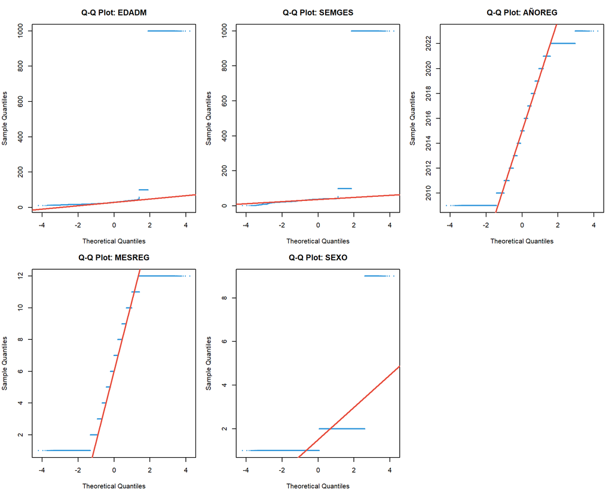

```r
vars_clave <- c("EDADM", "SEMGES", "AÑOREG", "MESREG", "SEXO")
vars_graficar <- vars_clave[vars_clave %in% vars_numericas]

par(mfrow = c(2, 3), mar = c(4, 4, 3, 1))

for(var in vars_graficar) {
  datos_var <- datos[[var]][!is.na(datos[[var]])]
  qqnorm(datos_var, main = paste("Q-Q Plot:", var),
         col = "#3498db", pch = 20, cex = 0.5)
  qqline(datos_var, col = "#e74c3c", lwd = 2)
}

par(mfrow = c(1, 1))
```

### 3.3.2 Histogramas

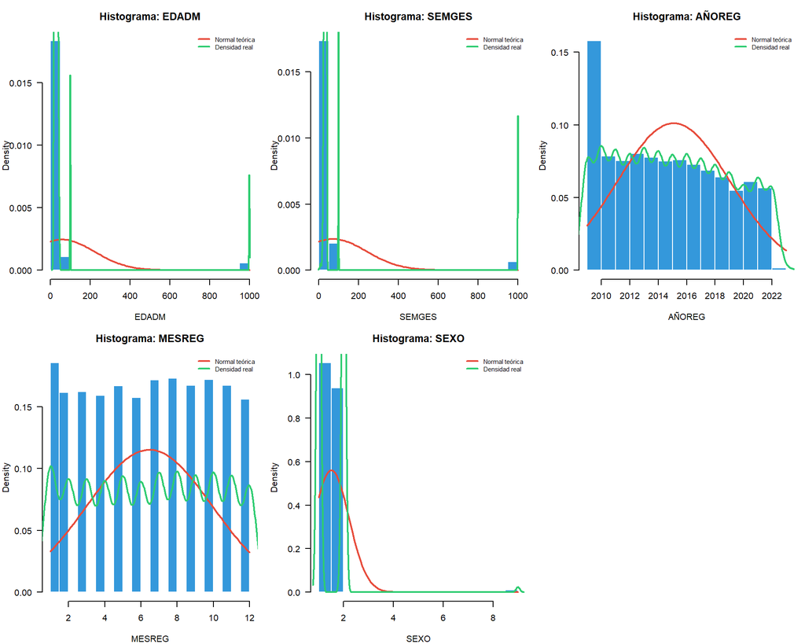

```r
par(mfrow = c(2, 3), mar = c(4, 4, 3, 1))

for(var in vars_graficar) {
  datos_var <- datos[[var]][!is.na(datos[[var]])]

  hist(datos_var,
       probability = TRUE,
       main = paste("Histograma:", var),
       xlab = var,
       col = "#3498db",
       border = "white",
       las = 1)

  curve(dnorm(x, mean = mean(datos_var), sd = sd(datos_var)),
        add = TRUE, col = "#e74c3c", lwd = 2)

  lines(density(datos_var), col = "#2ecc71", lwd = 2)

  legend("topright",
         legend = c("Normal teórica", "Densidad real"),
         col = c("#e74c3c", "#2ecc71"),
         lwd = 2, cex = 0.7, bty = "n")
}

par(mfrow = c(1, 1))
```

## 3.4 Tipo de Distribución

```r
identificar_distribucion <- function(asimetria, curtosis) {
  if(abs(asimetria) < 0.5 && abs(curtosis - 3) < 0.5) {
    return("📊 Aproximadamente Normal")
  } else if(asimetria > 1) {
    return("📈 Sesgada a la derecha")
  } else if(asimetria < -1) {
    return("📉 Sesgada a la izquierda")
  } else if(curtosis > 4) {
    return("🔺 Leptocúrtica")
  } else if(curtosis < 2) {
    return("🔻 Platicúrtica")
  } else {
    return("〰️ Asimétrica")
  }
}

resumen_numericas$Tipo_Distribucion <- mapply(
  identificar_distribucion,
  resumen_numericas$Asimetria,
  resumen_numericas$Curtosis
)

resumen_numericas %>%
  select(Variable, Asimetria, Curtosis, Tipo_Distribucion) %>%
  mutate(
    Asimetria = round(Asimetria, 2),
    Curtosis = round(Curtosis, 2)
  ) %>%
  kable(
    caption = "Tabla 6: Clasificación de Distribuciones",
    col.names = c("Variable", "Asimetría", "Curtosis", "Tipo de Distribución"),
    align = c('l', 'r', 'r', 'l')
  ) %>%
  kable_styling(
    bootstrap_options = c("striped", "hover"),
    full_width = FALSE
  ) %>%
  row_spec(0, bold = TRUE, color = "white", background = "#f39c12") %>%
  scroll_box(width = "100%", height = "400px")
```

Tabla 6: Clasificación de Distribuciones

|  | Variable | Asimetría | Curtosis | Tipo de Distribución |
| --- | --- | --- | --- | --- |
| 25% | DEPREG | 0.16 | 1.76 | 🔻 Platicúrtica \| |
| 25%1 | MUPREG | 0.16 | 1.75 | 🔻 Platicúrtica \| |
| 25%2 | MESREG | -0.02 | 1.78 | 🔻 Platicúrtica \| |
| 25%3 | AÑOREG | 0.13 | 1.87 | 🔻 Platicúrtica \| |
| 25%4 | DEPOCU | 0.16 | 1.76 | 🔻 Platicúrtica \| |
| 25%5 | MUPOCU | 0.16 | 1.75 | 🔻 Platicúrtica \| |
| 25%6 | AREAG | 2.45 | 7.23 | 📈 Sesgada a la derecha \| |
| 25%7 | SEXO | 5.32 | 56.57 | 📈 Sesgada a la derecha \| |
| 25%8 | DIAOCU | 0.02 | 1.81 | 🔻 Platicúrtica \| |
| 25%9 | MESOCU | -0.02 | 1.79 | 🔻 Platicúrtica \| |
| 25%10 | AÑOOCU | -2.64 | 7.97 | 📉 Sesgada a la izquierda \| |
| 25%11 | TIPAR | 3.97 | 16.92 | 📈 Sesgada a la derecha \| |
| 25%12 | CLAPAR | 3.69 | 15.48 | 📈 Sesgada a la derecha \| |
| 25%13 | SEMGES | 5.25 | 28.96 | 📈 Sesgada a la derecha \| |
| 25%14 | EDADM | 5.54 | 32.10 | 📈 Sesgada a la derecha \| |
| 25%15 | DEPREM | 21.69 | 473.22 | 📈 Sesgada a la derecha \| |
| 25%16 | MUPREM | 2.55 | 7.98 | 📈 Sesgada a la derecha \| |
| 25%17 | GRETNM | 0.54 | 1.34 | 🔻 Platicúrtica \| |
| 25%18 | ESCIVM | 2.98 | 10.59 | 📈 Sesgada a la derecha \| |
| 25%19 | NACIOM | 7.79 | 61.87 | 📈 Sesgada a la derecha \| |
| 25%20 | OCUPAM | -3.85 | 16.65 | 📉 Sesgada a la izquierda \| |
| 25%21 | ASISREC | 2.19 | 7.28 | 📈 Sesgada a la derecha \| |
| 25%22 | SITIOOCU | 0.79 | 2.09 | 〰️ Asimétrica |
| 25%23 | TOHITE | 3.72 | 15.63 | 📈 Sesgada a la derecha \| |
| 25%24 | TOHINM | 3.01 | 10.39 | 📈 Sesgada a la derecha \| |
| 25%25 | TOHIVI | 3.74 | 15.74 | 📈 Sesgada a la derecha \| |
| 25%26 | VIAPAR | 1.27 | 2.62 | 📈 Sesgada a la derecha \| |
| 25%27 | ESCOLAM | 1.92 | 5.92 | 📈 Sesgada a la derecha \| |
| 25%28 | PAISREM | 4.33 | 19.76 | 📈 Sesgada a la derecha \| |
| 25%29 | PUEBLOPM | 1.19 | 3.58 | 📈 Sesgada a la derecha \| |
| 25%30 | NACIONM | 6.24 | 40.01 | 📈 Sesgada a la derecha \| |

# 4 Exploración de Variables Categóricas

## 4.1 Variables Categóricas Identificadas

```r
vars_categoricas <- c()

for(var in names(datos)) {
  if(is.character(datos[[var]])) {
    vars_categoricas <- c(vars_categoricas, var)
  } else if(is.numeric(datos[[var]])) {
    n_unicos <- length(unique(na.omit(datos[[var]])))
    if(n_unicos < 20) {
      vars_categoricas <- c(vars_categoricas, var)
    }
  }
}
```

**Total de variables categóricas identificadas:** 22

Variables: MESREG, AÑOREG, AREAG, SEXO, MESOCU, AÑOOCU, TIPAR, CLAPAR, GRETNM, ESCIVM, …

## 4.2 Tablas de Frecuencia

```r
crear_tabla_frecuencias <- function(variable, nombre_var) {
  tabla <- as.data.frame(table(variable, useNA = "ifany"))
  colnames(tabla) <- c(nombre_var, "Frecuencia")

  tabla$Freq_Relativa <- tabla$Frecuencia / sum(tabla$Frecuencia)
  tabla$Porcentaje <- round(tabla$Freq_Relativa * 100, 2)
  tabla$Freq_Acumulada <- cumsum(tabla$Frecuencia)
  tabla$Porc_Acumulado <- round(cumsum(tabla$Freq_Relativa) * 100, 2)

  return(tabla)
}
```

### 4.2.1 SEXO

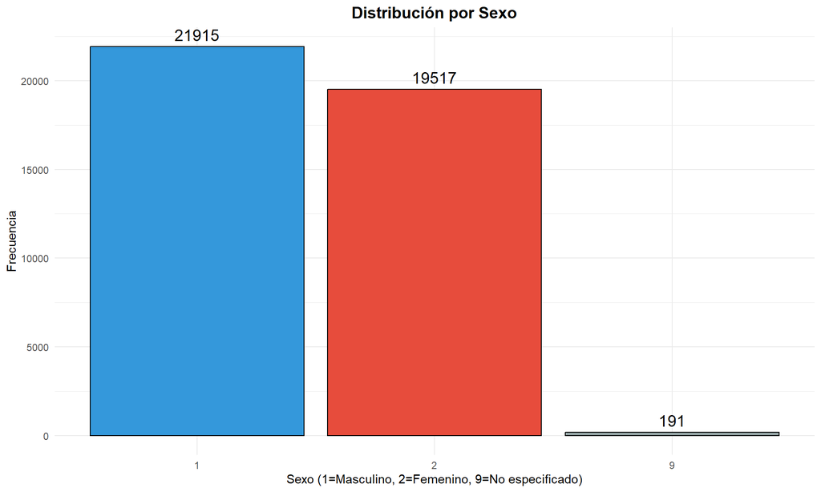

```r
if("SEXO" %in% names(datos)) {
  tabla <- crear_tabla_frecuencias(datos$SEXO, "SEXO")

  tabla %>%
    kable(
      caption = "Tabla 7: Distribución de Frecuencias - SEXO",
      align = c('c', 'r', 'r', 'r', 'r', 'r')
    ) %>%
    kable_styling(
      bootstrap_options = c("striped", "hover"),
      full_width = FALSE,
      position = "center"
    ) %>%
    row_spec(0, bold = TRUE, color = "white", background = "#3498db")

  # Gráfico
  ggplot(datos, aes(x = factor(SEXO), fill = factor(SEXO))) +
    geom_bar(color = "black") +
    geom_text(stat = 'count', aes(label = ..count..), vjust = -0.5, size = 5) +
    scale_fill_manual(values = c("#3498db", "#e74c3c", "#95a5a6")) +
    labs(
      title = "Distribución por Sexo",
      x = "Sexo (1=Masculino, 2=Femenino, 9=No especificado)",
      y = "Frecuencia"
    ) +
    theme_minimal() +
    theme(
      legend.position = "none",
      plot.title = element_text(hjust = 0.5, face = "bold", size = 14)
    )
}
```

### 4.2.2 ASISREC

```r
if("ASISREC" %in% names(datos)) {
  tabla <- crear_tabla_frecuencias(datos$ASISREC, "ASISREC")

  tabla %>%
    kable(
      caption = "Tabla 8: Distribución de Frecuencias - ASISREC (Asistencia Recibida)",
      align = c('c', 'r', 'r', 'r', 'r', 'r')
    ) %>%
    kable_styling(
      bootstrap_options = c("striped", "hover"),
      full_width = FALSE,
      position = "center"
    ) %>%
    row_spec(0, bold = TRUE, color = "white", background = "#2ecc71")
}
```

Tabla 8: Distribución de Frecuencias - ASISREC (Asistencia Recibida)

| ASISREC | Frecuencia | Freq_Relativa | Porcentaje | Freq_Acumulada | Porc_Acumulado |
| --- | --- | --- | --- | --- | --- |
| 1 | 28892 | 0.6941355 | 69.41 | 28892 | 69.41 |
| 2 | 661 | 0.0158806 | 1.59 | 29553 | 71.00 |
| 3 | 6129 | 0.1472503 | 14.73 | 35682 | 85.73 |
| 4 | 284 | 0.0068232 | 0.68 | 35966 | 86.41 |
| 5 | 3490 | 0.0838479 | 8.38 | 39456 | 94.79 |
| 9 | 2167 | 0.0520626 | 5.21 | 41623 | 100.00 |

### 4.2.3 SITIOOCU

```r
if("SITIOOCU" %in% names(datos)) {
  tabla <- crear_tabla_frecuencias(datos$SITIOOCU, "SITIOOCU")

  tabla %>%
    kable(
      caption = "Tabla 9: Distribución de Frecuencias - SITIOOCU (Sitio de Ocurrencia)",
      align = c('c', 'r', 'r', 'r', 'r', 'r')
    ) %>%
    kable_styling(
      bootstrap_options = c("striped", "hover"),
      full_width = FALSE,
      position = "center"
    ) %>%
    row_spec(0, bold = TRUE, color = "white", background = "#9b59b6")
}
```

Tabla 9: Distribución de Frecuencias - SITIOOCU (Sitio de Ocurrencia)

| SITIOOCU | Frecuencia | Freq_Relativa | Porcentaje | Freq_Acumulada | Porc_Acumulado |
| --- | --- | --- | --- | --- | --- |
| 1 | 21784 | 0.5233645 | 52.34 | 21784 | 52.34 |
| 2 | 2335 | 0.0560988 | 5.61 | 24119 | 57.95 |
| 3 | 1074 | 0.0258030 | 2.58 | 25193 | 60.53 |
| 4 | 2229 | 0.0535521 | 5.36 | 27422 | 65.88 |
| 5 | 62 | 0.0014896 | 0.15 | 27484 | 66.03 |
| 6 | 8341 | 0.2003940 | 20.04 | 35825 | 86.07 |
| 7 | 18 | 0.0004325 | 0.04 | 35843 | 86.11 |
| 8 | 76 | 0.0018259 | 0.18 | 35919 | 86.30 |
| 9 | 5704 | 0.1370396 | 13.70 | 41623 | 100.00 |

### 4.2.4 CAUDEF

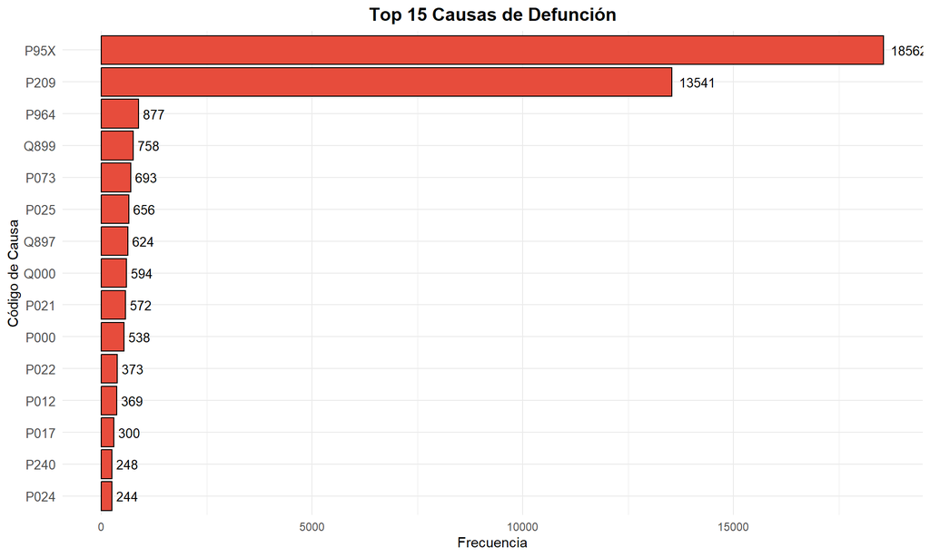

```r
if("CAUDEF" %in% names(datos)) {
  tabla <- crear_tabla_frecuencias(datos$CAUDEF, "CAUDEF")

  # Mostrar top 20
  tabla_top20 <- head(tabla[order(-tabla$Frecuencia), ], 20)

  tabla_top20 %>%
    kable(
      caption = "Tabla 10: Top 20 Causas de Defunción más Frecuentes",
      align = c('l', 'r', 'r', 'r', 'r', 'r')
    ) %>%
    kable_styling(
      bootstrap_options = c("striped", "hover"),
      full_width = FALSE,
      position = "center"
    ) %>%
    row_spec(0, bold = TRUE, color = "white", background = "#e74c3c") %>%
    scroll_box(width = "100%", height = "500px")

  # Gráfico Top 15
  top15 <- head(tabla[order(-tabla$Frecuencia), ], 15)

  ggplot(top15, aes(x = reorder(CAUDEF, Frecuencia), y = Frecuencia)) +
    geom_bar(stat = "identity", fill = "#e74c3c", color = "black") +
    coord_flip() +
    geom_text(aes(label = Frecuencia), hjust = -0.2, size = 3.5) +
    labs(
      title = "Top 15 Causas de Defunción",
      x = "Código de Causa",
      y = "Frecuencia"
    ) +
    theme_minimal() +
    theme(
      plot.title = element_text(hjust = 0.5, face = "bold", size = 14),
      axis.text.y = element_text(size = 10)
    )
}
```

# 5 Gráficos Exploratorios

A continuación se presentan gráficos exploratorios que permiten visualizar el estado general de los datos, identificar patrones, valores atípicos y distribuciones antes de profundizar en relaciones entre variables.

## 5.1 Distribución de Variables Numéricas Clave

### 5.1.1 Boxplots Comparativos

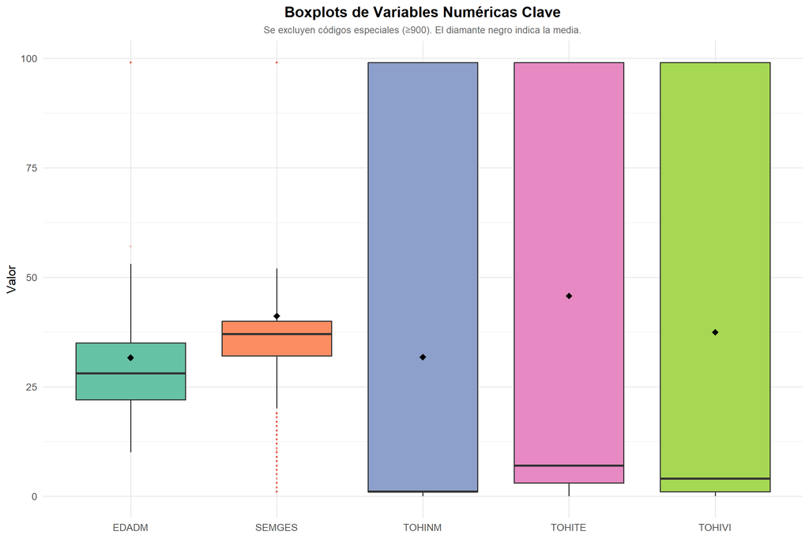

```r
vars_boxplot <- c("EDADM", "SEMGES", "TOHITE", "TOHINM", "TOHIVI")
vars_boxplot <- vars_boxplot[vars_boxplot %in% names(datos)]

if(length(vars_boxplot) > 0) {
  datos_long <- datos %>%
    select(all_of(vars_boxplot)) %>%
    pivot_longer(cols = everything(), names_to = "Variable", values_to = "Valor") %>%
    filter(!is.na(Valor), Valor < 900)

  ggplot(datos_long, aes(x = Variable, y = Valor, fill = Variable)) +
    geom_boxplot(outlier.color = "#e74c3c", outlier.alpha = 0.3, outlier.size = 0.8) +
    stat_summary(fun = mean, geom = "point", shape = 18, size = 3, color = "black") +
    scale_fill_brewer(palette = "Set2") +
    labs(
      title = "Boxplots de Variables Numéricas Clave",
      subtitle = "Se excluyen códigos especiales (≥900). El diamante negro indica la media.",
      x = NULL, y = "Valor"
    ) +
    theme_minimal(base_size = 13) +
    theme(
      plot.title = element_text(hjust = 0.5, face = "bold"),
      plot.subtitle = element_text(hjust = 0.5, size = 10, color = "gray40"),
      legend.position = "none"
    )
}
```

### 5.1.2 Densidades Superpuestas

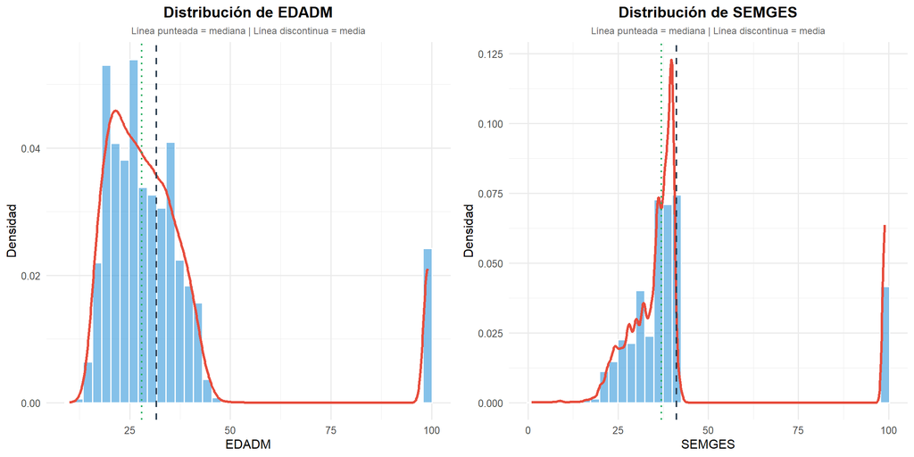

```r
vars_densidad <- c("EDADM", "SEMGES")
vars_densidad <- vars_densidad[vars_densidad %in% names(datos)]

if(length(vars_densidad) > 0) {
  plots_densidad <- list()

  for(v in vars_densidad) {
    datos_filtrados <- datos %>%
      filter(!is.na(.data[[v]]), .data[[v]] < 900)

    p <- ggplot(datos_filtrados, aes(x = .data[[v]])) +
      geom_histogram(aes(y = after_stat(density)), bins = 40,
                     fill = "#3498db", color = "white", alpha = 0.6) +
      geom_density(color = "#e74c3c", linewidth = 1.2) +
      geom_vline(aes(xintercept = mean(.data[[v]], na.rm = TRUE)),
                 color = "#2c3e50", linetype = "dashed", linewidth = 0.8) +
      geom_vline(aes(xintercept = median(.data[[v]], na.rm = TRUE)),
                 color = "#27ae60", linetype = "dotted", linewidth = 0.8) +
      labs(
        title = paste("Distribución de", v),
        subtitle = "Línea punteada = mediana | Línea discontinua = media",
        x = v, y = "Densidad"
      ) +
      theme_minimal(base_size = 12) +
      theme(plot.title = element_text(hjust = 0.5, face = "bold"),
            plot.subtitle = element_text(hjust = 0.5, size = 9, color = "gray40"))

    plots_densidad[[v]] <- p
  }

  do.call(grid.arrange, c(plots_densidad, ncol = length(plots_densidad)))
}
```

## 5.2 Composición de Variables Categóricas

### 5.2.1 Distribución por Sexo

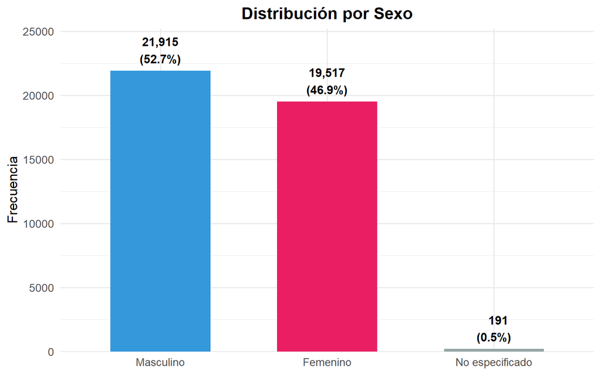

```r
if("SEXO" %in% names(datos)) {
  datos_sexo <- datos %>%
    filter(!is.na(SEXO)) %>%
    mutate(SEXO_label = case_when(
      SEXO == 1 ~ "Masculino",
      SEXO == 2 ~ "Femenino",
      SEXO == 9 ~ "No especificado",
      TRUE ~ as.character(SEXO)
    )) %>%
    count(SEXO_label) %>%
    mutate(porcentaje = round(n / sum(n) * 100, 1))

  ggplot(datos_sexo, aes(x = reorder(SEXO_label, -n), y = n, fill = SEXO_label)) +
    geom_col(width = 0.6, show.legend = FALSE) +
    geom_text(aes(label = paste0(format(n, big.mark = ","), "\n(", porcentaje, "%)")),
              vjust = -0.3, size = 4, fontface = "bold") +
    scale_fill_manual(values = c("Masculino" = "#3498db", "Femenino" = "#e91e63",
                                 "No especificado" = "#95a5a6")) +
    labs(title = "Distribución por Sexo", x = NULL, y = "Frecuencia") +
    theme_minimal(base_size = 13) +
    theme(plot.title = element_text(hjust = 0.5, face = "bold")) +
    scale_y_continuous(expand = expansion(mult = c(0, 0.15)))
}
```

### 5.2.2 Área Geográfica

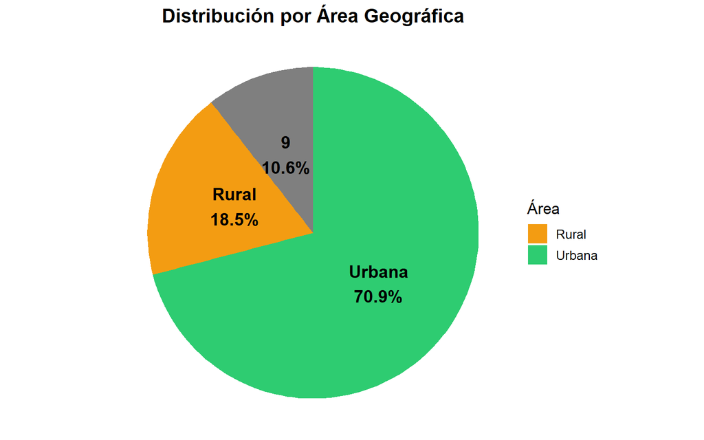

```r
if("AREAG" %in% names(datos)) {
  datos_area <- datos %>%
    filter(!is.na(AREAG)) %>%
    mutate(AREAG_label = case_when(
      AREAG == 1 ~ "Urbana",
      AREAG == 2 ~ "Rural",
      TRUE ~ as.character(AREAG)
    )) %>%
    count(AREAG_label) %>%
    mutate(porcentaje = round(n / sum(n) * 100, 1))

  ggplot(datos_area, aes(x = "", y = n, fill = AREAG_label)) +
    geom_col(width = 1) +
    coord_polar(theta = "y") +
    geom_text(aes(label = paste0(AREAG_label, "\n", porcentaje, "%")),
              position = position_stack(vjust = 0.5), size = 5, fontface = "bold") +
    scale_fill_manual(values = c("Urbana" = "#2ecc71", "Rural" = "#f39c12")) +
    labs(title = "Distribución por Área Geográfica", fill = "Área") +
    theme_void(base_size = 13) +
    theme(plot.title = element_text(hjust = 0.5, face = "bold"))
}
```

### 5.2.3 Asistencia Recibida

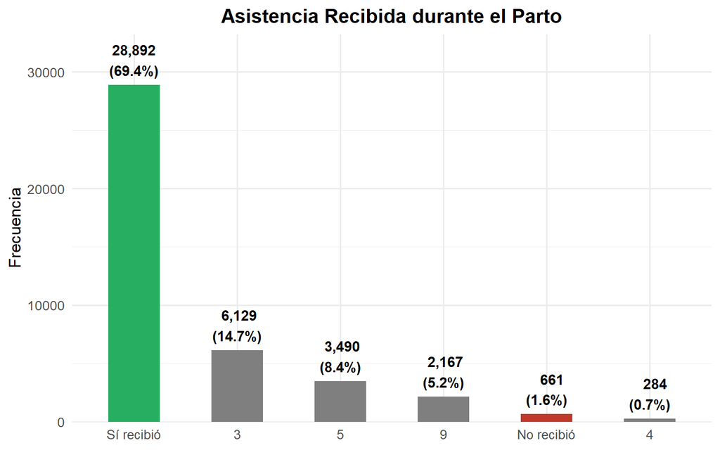

```r
if("ASISREC" %in% names(datos)) {
  datos_asis <- datos %>%
    filter(!is.na(ASISREC)) %>%
    mutate(ASISREC_label = case_when(
      ASISREC == 1 ~ "Sí recibió",
      ASISREC == 2 ~ "No recibió",
      TRUE ~ as.character(ASISREC)
    )) %>%
    count(ASISREC_label) %>%
    mutate(porcentaje = round(n / sum(n) * 100, 1))

  ggplot(datos_asis, aes(x = reorder(ASISREC_label, -n), y = n, fill = ASISREC_label)) +
    geom_col(width = 0.5, show.legend = FALSE) +
    geom_text(aes(label = paste0(format(n, big.mark = ","), "\n(", porcentaje, "%)")),
              vjust = -0.3, size = 4, fontface = "bold") +
    scale_fill_manual(values = c("Sí recibió" = "#27ae60", "No recibió" = "#c0392b")) +
    labs(title = "Asistencia Recibida durante el Parto", x = NULL, y = "Frecuencia") +
    theme_minimal(base_size = 13) +
    theme(plot.title = element_text(hjust = 0.5, face = "bold")) +
    scale_y_continuous(expand = expansion(mult = c(0, 0.15)))
}
```

## 5.3 Panorama Temporal

### 5.3.1 Registros por Año

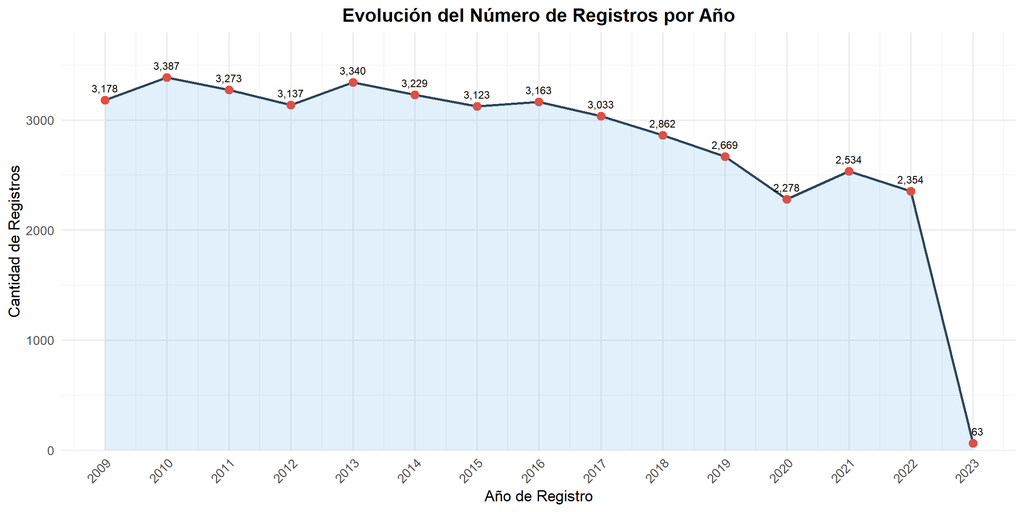

```r
if("AÑOREG" %in% names(datos)) {
  registros_anio <- datos %>%
    filter(!is.na(AÑOREG)) %>%
    count(AÑOREG)

  ggplot(registros_anio, aes(x = AÑOREG, y = n)) +
    geom_line(color = "#2c3e50", linewidth = 1) +
    geom_point(color = "#e74c3c", size = 3) +
    geom_area(alpha = 0.15, fill = "#3498db") +
    geom_text(aes(label = format(n, big.mark = ",")), vjust = -1, size = 3.2) +
    labs(
      title = "Evolución del Número de Registros por Año",
      x = "Año de Registro", y = "Cantidad de Registros"
    ) +
    scale_x_continuous(breaks = seq(min(registros_anio$AÑOREG), max(registros_anio$AÑOREG), 1)) +
    theme_minimal(base_size = 13) +
    theme(
      plot.title = element_text(hjust = 0.5, face = "bold"),
      axis.text.x = element_text(angle = 45, hjust = 1)
    ) +
    scale_y_continuous(expand = expansion(mult = c(0, 0.12)))
}
```

### 5.3.2 Distribución Mensual

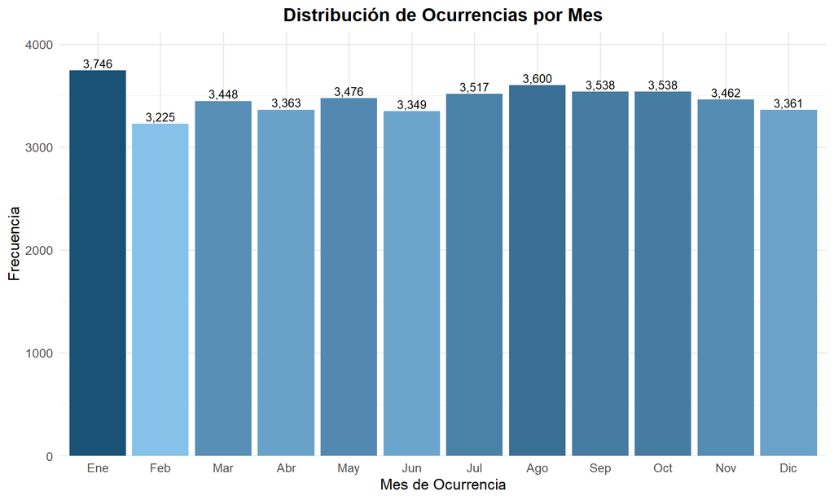

```r
if("MESOCU" %in% names(datos)) {
  meses_nombres <- c("Ene", "Feb", "Mar", "Abr", "May", "Jun",
                     "Jul", "Ago", "Sep", "Oct", "Nov", "Dic")

  registros_mes <- datos %>%
    filter(!is.na(MESOCU), MESOCU >= 1, MESOCU <= 12) %>%
    count(MESOCU) %>%
    mutate(Mes = factor(meses_nombres[MESOCU], levels = meses_nombres))

  ggplot(registros_mes, aes(x = Mes, y = n, fill = n)) +
    geom_col(show.legend = FALSE) +
    scale_fill_gradient(low = "#85c1e9", high = "#1a5276") +
    geom_text(aes(label = format(n, big.mark = ",")), vjust = -0.3, size = 3.5) +
    labs(
      title = "Distribución de Ocurrencias por Mes",
      x = "Mes de Ocurrencia", y = "Frecuencia"
    ) +
    theme_minimal(base_size = 13) +
    theme(plot.title = element_text(hjust = 0.5, face = "bold")) +
    scale_y_continuous(expand = expansion(mult = c(0, 0.1)))
}
```

## 5.4 Detección de Valores Atípicos y Datos Faltantes

```r
vars_revision <- c("EDADM", "SEMGES", "TOHITE", "TOHINM", "TOHIVI", "ESCOLAM")
vars_revision <- vars_revision[vars_revision %in% names(datos)]

if(length(vars_revision) > 0) {
  resumen_atipicos <- data.frame(
    Variable = character(),
    N_total = integer(),
    N_NA = integer(),
    Porc_NA = numeric(),
    N_codigo_999 = integer(),
    Porc_999 = numeric(),
    stringsAsFactors = FALSE
  )

  for(v in vars_revision) {
    vals <- datos[[v]]
    n_total <- length(vals)
    n_na <- sum(is.na(vals))
    n_999 <- sum(vals >= 99 & !is.na(vals))

    resumen_atipicos <- rbind(resumen_atipicos, data.frame(
      Variable = v,
      N_total = n_total,
      N_NA = n_na,
      Porc_NA = round(n_na / n_total * 100, 2),
      N_codigo_999 = n_999,
      Porc_999 = round(n_999 / n_total * 100, 2)
    ))
  }

  resumen_atipicos %>%
    kable(
      caption = "Detección de Valores Atípicos y Códigos Especiales",
      col.names = c("Variable", "N Total", "N Faltantes (NA)", "% NA",
                     "N Códigos ≥99", "% Códigos ≥99"),
      align = c('l', rep('r', 5))
    ) %>%
    kable_styling(
      bootstrap_options = c("striped", "hover", "condensed"),
      full_width = FALSE
    ) %>%
    row_spec(0, bold = TRUE, color = "white", background = "#8e44ad")
}
```

Detección de Valores Atípicos y Códigos Especiales

| Variable | N Total | N Faltantes (NA) | % NA | N Códigos ≥99 | % Códigos ≥99 |
| --- | --- | --- | --- | --- | --- |
| EDADM | 41623 | 0 | 0.00 | 3429 | 8.24 |
| SEMGES | 41623 | 0 | 0.00 | 5531 | 13.29 |
| TOHITE | 41623 | 351 | 0.84 | 19353 | 46.50 |
| TOHINM | 41623 | 142 | 0.34 | 15159 | 36.42 |
| TOHIVI | 41623 | 258 | 0.62 | 16343 | 39.26 |
| ESCOLAM | 41623 | 3233 | 7.77 | 0 | 0.00 |

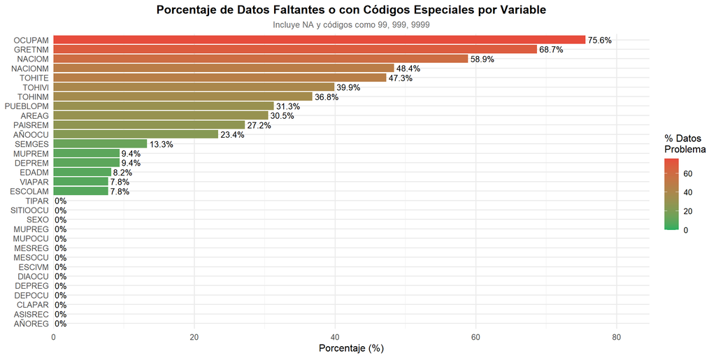

```r
vars_heatmap <- names(datos)[sapply(datos, is.numeric)]

porc_faltantes <- sapply(datos[vars_heatmap], function(x) {
  na_real <- sum(is.na(x))
  cod_especial <- sum(x %in% c(99, 999, 9999) & !is.na(x))
  round((na_real + cod_especial) / length(x) * 100, 1)
})

df_faltantes <- data.frame(
  Variable = names(porc_faltantes),
  Porcentaje = as.numeric(porc_faltantes)
) %>%
  arrange(desc(Porcentaje))

ggplot(df_faltantes, aes(x = reorder(Variable, Porcentaje), y = Porcentaje, fill = Porcentaje)) +
  geom_col() +
  coord_flip() +
  scale_fill_gradient(low = "#27ae60", high = "#e74c3c", name = "% Datos\nProblema") +
  geom_text(aes(label = paste0(Porcentaje, "%")), hjust = -0.1, size = 3.5) +
  labs(
    title = "Porcentaje de Datos Faltantes o con Códigos Especiales por Variable",
    subtitle = "Incluye NA y códigos como 99, 999, 9999",
    x = NULL, y = "Porcentaje (%)"
  ) +
  theme_minimal(base_size = 12) +
  theme(
    plot.title = element_text(hjust = 0.5, face = "bold"),
    plot.subtitle = element_text(hjust = 0.5, size = 10, color = "gray40")
  ) +
  scale_y_continuous(expand = expansion(mult = c(0, 0.12)))
```

**Observaciones de los Gráficos Exploratorios:**

- 📊 Los **boxplots** revelan la presencia de valores extremos que probablemente corresponden a códigos de datos faltantes (99, 999, 9999)
- 📈 Las **distribuciones de densidad** muestran el sesgo y la forma real de las variables clave
- 🗓️ La **tendencia temporal** permite identificar cambios en el volumen de registros a lo largo de los años
- 📅 La **distribución mensual** muestra si existe estacionalidad en las ocurrencias
- ⚠️ El gráfico de **datos faltantes** ayuda a priorizar qué variables necesitan limpieza antes de análisis posteriores

# 6 Relaciones entre Variables

## 6.1 Análisis de Correlación

### 6.1.1 Matriz de Correlación

```r
# Seleccionar variables numéricas continuas clave para correlación
vars_correlacion <- c("AÑOREG", "MESREG", "EDADM", "SEMGES",
                      "TOHITE", "TOHINM", "TOHIVI", "ESCOLAM")

# Filtrar solo las que existen en el dataset
vars_correlacion <- vars_correlacion[vars_correlacion %in% names(datos)]

# Crear subset sin NAs
datos_corr <- datos[, vars_correlacion]
datos_corr <- na.omit(datos_corr)

# Calcular matriz de correlación
matriz_correlacion <- cor(datos_corr)

# Mostrar matriz en tabla
matriz_correlacion %>%
  round(3) %>%
  kable(
    caption = "Tabla 11: Matriz de Correlación de Pearson",
    align = 'c'
  ) %>%
  kable_styling(
    bootstrap_options = c("striped", "hover"),
    full_width = FALSE,
    font_size = 11
  ) %>%
  row_spec(0, bold = TRUE, color = "white", background = "#e74c3c")
```

Tabla 11: Matriz de Correlación de Pearson

|  | AÑOREG | MESREG | EDADM | SEMGES | TOHITE | TOHINM | TOHIVI | ESCOLAM |
| --- | --- | --- | --- | --- | --- | --- | --- | --- |
| AÑOREG | 1.000 | -0.006 | -0.048 | -0.224 | 0.077 | 0.358 | 0.222 | -0.025 |
| MESREG | -0.006 | 1.000 | -0.015 | -0.020 | -0.010 | -0.004 | -0.004 | -0.009 |
| EDADM | -0.048 | -0.015 | 1.000 | -0.011 | 0.070 | 0.050 | 0.088 | 0.171 |
| SEMGES | -0.224 | -0.020 | -0.011 | 1.000 | -0.059 | -0.107 | -0.087 | -0.068 |
| TOHITE | 0.077 | -0.010 | 0.070 | -0.059 | 1.000 | 0.743 | 0.846 | 0.176 |
| TOHINM | 0.358 | -0.004 | 0.050 | -0.107 | 0.743 | 1.000 | 0.599 | 0.110 |
| TOHIVI | 0.222 | -0.004 | 0.088 | -0.087 | 0.846 | 0.599 | 1.000 | 0.166 |
| ESCOLAM | -0.025 | -0.009 | 0.171 | -0.068 | 0.176 | 0.110 | 0.166 | 1.000 |

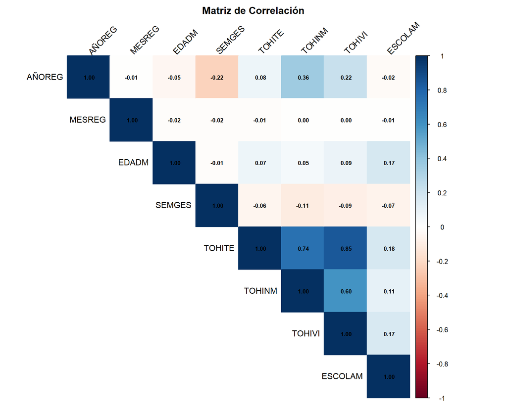

```r
# Visualizar matriz de correlación
corrplot(matriz_correlacion,
         method = "color",
         type = "upper",
         addCoef.col = "black",
         number.cex = 0.7,
         tl.col = "black",
         tl.srt = 45,
         title = "Matriz de Correlación",
         mar = c(0, 0, 2, 0))
```

### 6.1.2 Correlaciones Significativas

```r
# Identificar correlaciones significativas (|r| > 0.3)
correlaciones_significativas <- data.frame()

for(i in 1:(ncol(matriz_correlacion)-1)) {
  for(j in (i+1):ncol(matriz_correlacion)) {
    cor_valor <- matriz_correlacion[i, j]
    if(abs(cor_valor) > 0.3) {
      correlaciones_significativas <- rbind(
        correlaciones_significativas,
        data.frame(
          Variable_1 = rownames(matriz_correlacion)[i],
          Variable_2 = colnames(matriz_correlacion)[j],
          Correlacion = cor_valor,
          Fuerza = ifelse(abs(cor_valor) > 0.7, "Fuerte",
                   ifelse(abs(cor_valor) > 0.5, "Moderada", "Débil")),
          Direccion = ifelse(cor_valor > 0, "Positiva", "Negativa")
        )
      )
    }
  }
}

# Ordenar por valor absoluto de correlación
if(nrow(correlaciones_significativas) > 0) {
  correlaciones_significativas <- correlaciones_significativas[
    order(-abs(correlaciones_significativas$Correlacion)),
  ]

  correlaciones_significativas %>%
    mutate(Correlacion = round(Correlacion, 3)) %>%
    kable(
      caption = "Tabla 12: Correlaciones Significativas (|r| > 0.3)",
      col.names = c("Variable 1", "Variable 2", "r", "Fuerza", "Dirección"),
      align = c('l', 'l', 'r', 'c', 'c')
    ) %>%
    kable_styling(
      bootstrap_options = c("striped", "hover"),
      full_width = FALSE
    ) %>%
    row_spec(0, bold = TRUE, color = "white", background = "#2ecc71")
} else {
  cat("No se encontraron correlaciones significativas (|r| > 0.3)\n")
}
```

Tabla 12: Correlaciones Significativas (|r| > 0.3)

|  | Variable 1 | Variable 2 | r | Fuerza | Dirección |
| --- | --- | --- | --- | --- | --- |
| 3 | TOHITE | TOHIVI | 0.846 | Fuerte | Positiva |
| 2 | TOHITE | TOHINM | 0.743 | Fuerte | Positiva |
| 4 | TOHINM | TOHIVI | 0.599 | Moderada | Positiva |
| 1 | AÑOREG | TOHINM | 0.358 | Débil | Positiva |

## 6.2 Gráficos de Dispersión

### 6.2.1 Edad vs Semanas de Gestación

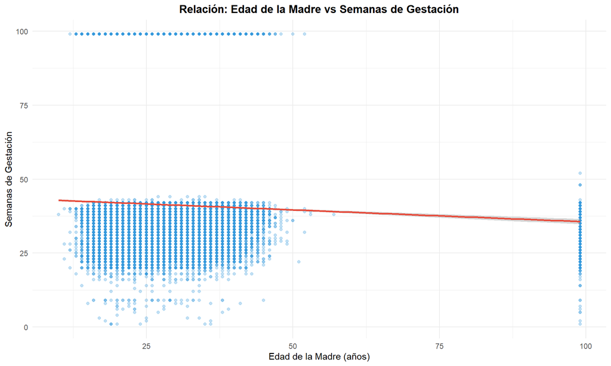

```r
if("EDADM" %in% names(datos) && "SEMGES" %in% names(datos)) {
  ggplot(datos %>% filter(EDADM < 100, SEMGES < 100),
         aes(x = EDADM, y = SEMGES)) +
    geom_point(alpha = 0.3, color = "#3498db") +
    geom_smooth(method = "lm", color = "#e74c3c", se = TRUE) +
    labs(
      title = "Relación: Edad de la Madre vs Semanas de Gestación",
      x = "Edad de la Madre (años)",
      y = "Semanas de Gestación"
    ) +
    theme_minimal() +
    theme(plot.title = element_text(hjust = 0.5, face = "bold"))
}
```

### 6.2.2 Edad vs Total de Hijos

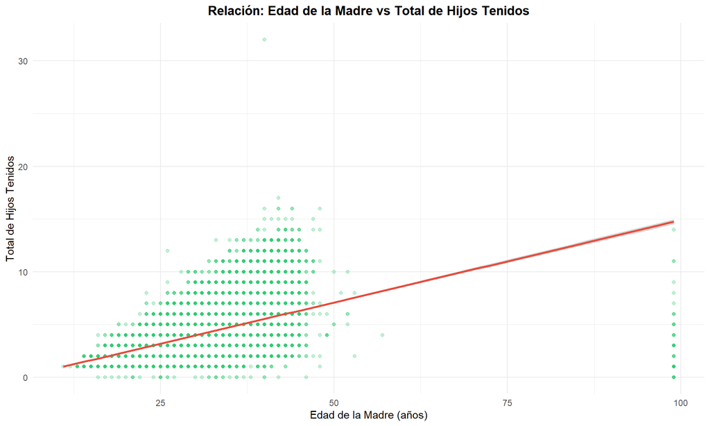

```r
if("EDADM" %in% names(datos) && "TOHITE" %in% names(datos)) {
  ggplot(datos %>% filter(EDADM < 100, TOHITE < 50),
         aes(x = EDADM, y = TOHITE)) +
    geom_point(alpha = 0.3, color = "#2ecc71") +
    geom_smooth(method = "lm", color = "#e74c3c", se = TRUE) +
    labs(
      title = "Relación: Edad de la Madre vs Total de Hijos Tenidos",
      x = "Edad de la Madre (años)",
      y = "Total de Hijos Tenidos"
    ) +
    theme_minimal() +
    theme(plot.title = element_text(hjust = 0.5, face = "bold"))
}
```

### 6.2.3 Semanas vs Hijos Vivos

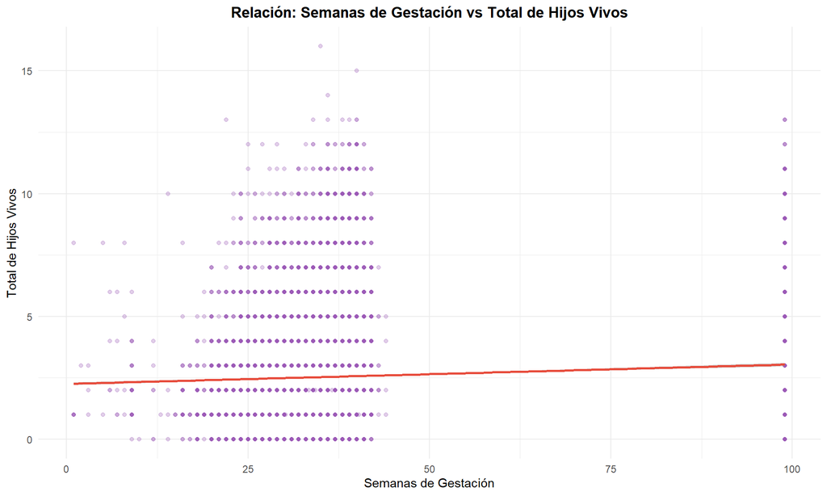

```r
if("SEMGES" %in% names(datos) && "TOHIVI" %in% names(datos)) {
  ggplot(datos %>% filter(SEMGES < 100, TOHIVI < 50),
         aes(x = SEMGES, y = TOHIVI)) +
    geom_point(alpha = 0.3, color = "#9b59b6") +
    geom_smooth(method = "lm", color = "#e74c3c", se = TRUE) +
    labs(
      title = "Relación: Semanas de Gestación vs Total de Hijos Vivos",
      x = "Semanas de Gestación",
      y = "Total de Hijos Vivos"
    ) +
    theme_minimal() +
    theme(plot.title = element_text(hjust = 0.5, face = "bold"))
}
```

## 6.3 Tablas de Contingencia

### 6.3.1 SEXO vs ASISREC

```r
if("SEXO" %in% names(datos) && "ASISREC" %in% names(datos)) {
  # Crear tabla
  tabla_sexo_asis <- table(datos$SEXO, datos$ASISREC)

  # Mostrar tabla con totales
  addmargins(tabla_sexo_asis) %>%
    kable(
      caption = "Tabla 13: Tabla de Contingencia - SEXO vs ASISREC"
    ) %>%
    kable_styling(
      bootstrap_options = c("striped", "hover"),
      full_width = FALSE
    ) %>%
    row_spec(0, bold = TRUE, color = "white", background = "#3498db")

  # Proporciones por fila (%) - CORRECCIÓN AQUÍ
  cat("\n\nProporciones por fila (%):\n")

  (prop.table(tabla_sexo_asis, 1) * 100) %>%
    round(2) %>%
    kable(caption = "Porcentajes por fila") %>%
    kable_styling(bootstrap_options = c("striped", "hover")) %>%
    print()

  # Test de independencia Chi-cuadrado
  test_chi <- chisq.test(tabla_sexo_asis)

  cat("\n\n**Test de Independencia Chi-cuadrado:**\n")
  cat("- Estadístico χ²:", round(test_chi$statistic, 4), "\n")
  cat("- p-valor:", format.pval(test_chi$p.value, digits = 4), "\n")

  if(test_chi$p.value < 0.05) {
    cat("\n**Conclusión:** Las variables NO son independientes (p < 0.05)\n")
    cat("Existe una relación estadísticamente significativa entre SEXO y ASISREC\n")
  } else {
    cat("\n**Conclusión:** Las variables son independientes (p >= 0.05)\n")
    cat("No hay evidencia de relación entre SEXO y ASISREC\n")
  }
}
```

[output not shown]

```
##
##
## **Test de Independencia Chi-cuadrado:**
## - Estadístico χ²: 110.0828
## - p-valor: < 2.2e-16
##
## **Conclusión:** Las variables NO son independientes (p < 0.05)
## Existe una relación estadísticamente significativa entre SEXO y ASISREC
```

### 6.3.2 SEXO vs SITIOOCU

```r
if("SEXO" %in% names(datos) && "SITIOOCU" %in% names(datos)) {
  tabla_sexo_sitio <- table(datos$SEXO, datos$SITIOOCU)

  addmargins(tabla_sexo_sitio) %>%
    kable(
      caption = "Tabla 14: Tabla de Contingencia - SEXO vs SITIOOCU"
    ) %>%
    kable_styling(
      bootstrap_options = c("striped", "hover"),
      full_width = FALSE
    ) %>%
    row_spec(0, bold = TRUE, color = "white", background = "#2ecc71")

  # Test Chi-cuadrado
  test_chi2 <- chisq.test(tabla_sexo_sitio)
  cat("\n**Chi-cuadrado p-valor:**", format.pval(test_chi2$p.value, digits = 4), "\n")
}
```

```
##
## **Chi-cuadrado p-valor:** < 2.2e-16
```

### 6.3.3 AREAG vs ASISREC

```r
if("AREAG" %in% names(datos) && "ASISREC" %in% names(datos)) {
  tabla_area_asis <- table(datos$AREAG, datos$ASISREC)

  addmargins(tabla_area_asis) %>%
    kable(
      caption = "Tabla 15: Tabla de Contingencia - AREAG vs ASISREC"
    ) %>%
    kable_styling(
      bootstrap_options = c("striped", "hover"),
      full_width = FALSE
    ) %>%
    row_spec(0, bold = TRUE, color = "white", background = "#9b59b6")

  # Test Chi-cuadrado
  test_chi3 <- chisq.test(tabla_area_asis)
  cat("\n**Chi-cuadrado p-valor:**", format.pval(test_chi3$p.value, digits = 4), "\n")

  if(test_chi3$p.value < 0.05) {
    cat("\n**Conclusión:** El área geográfica SÍ influye en la asistencia recibida (p < 0.05)\n")
  } else {
    cat("\n**Conclusión:** El área geográfica NO influye significativamente en la asistencia (p >= 0.05)\n")
  }
}
```

```
##
## **Chi-cuadrado p-valor:** < 2.2e-16
##
## **Conclusión:** El área geográfica SÍ influye en la asistencia recibida (p < 0.05)
```

## 6.4 Visualizaciones de Relaciones

### 6.4.1 Barras Agrupadas

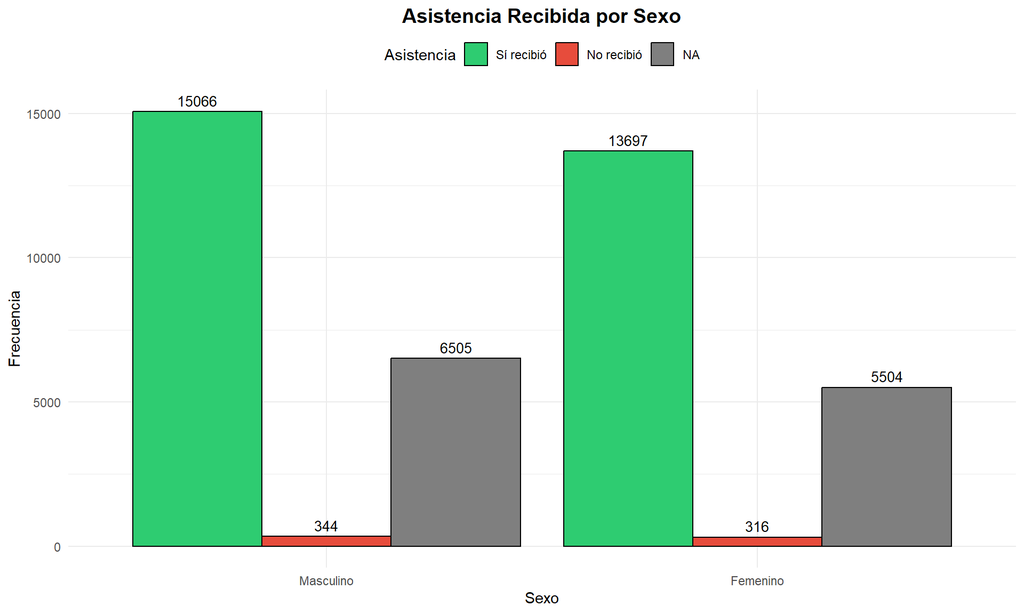

```r
if("SEXO" %in% names(datos) && "ASISREC" %in% names(datos)) {
  datos_graf <- datos %>%
    filter(!is.na(SEXO) & !is.na(ASISREC) & SEXO %in% c(1, 2)) %>%
    mutate(
      Sexo = factor(SEXO, levels = c(1, 2),
                    labels = c("Masculino", "Femenino")),
      Asistencia = factor(ASISREC, levels = c(1, 2),
                         labels = c("Sí recibió", "No recibió"))
    ) %>%
    group_by(Sexo, Asistencia) %>%
    summarise(Frecuencia = n(), .groups = "drop")

  ggplot(datos_graf, aes(x = Sexo, y = Frecuencia, fill = Asistencia)) +
    geom_bar(stat = "identity", position = "dodge", color = "black") +
    geom_text(aes(label = Frecuencia),
              position = position_dodge(width = 0.9),
              vjust = -0.5, size = 3.5) +
    scale_fill_manual(values = c("#2ecc71", "#e74c3c")) +
    labs(
      title = "Asistencia Recibida por Sexo",
      x = "Sexo",
      y = "Frecuencia",
      fill = "Asistencia"
    ) +
    theme_minimal() +
    theme(
      plot.title = element_text(hjust = 0.5, face = "bold", size = 14),
      legend.position = "top"
    )
}
```

### 6.4.2 Boxplots por Grupo

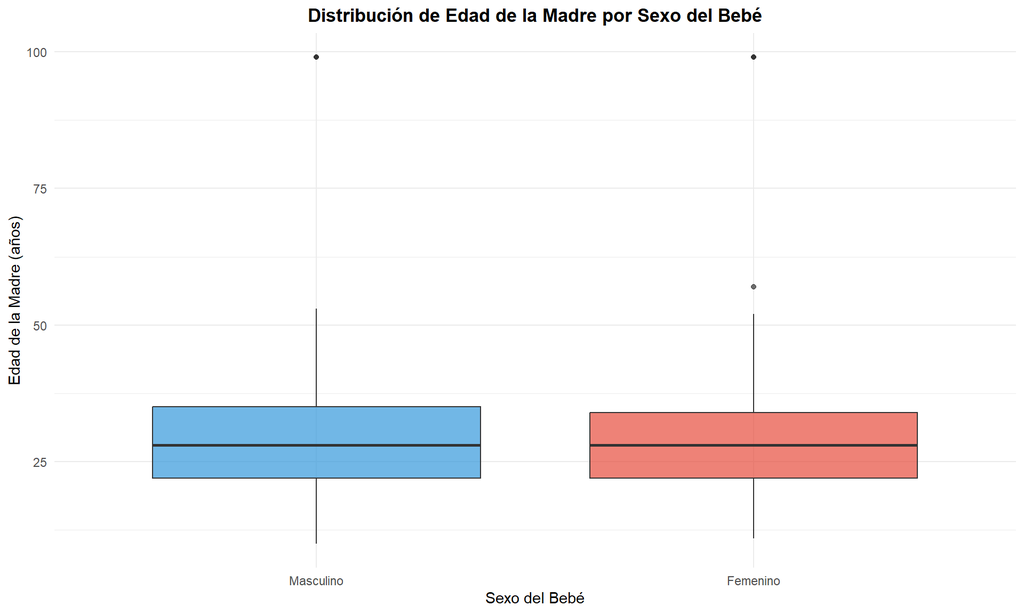

```r
# Boxplot: Edad de la Madre por Sexo del bebé
if("EDADM" %in% names(datos) && "SEXO" %in% names(datos)) {
  datos_box <- datos %>%
    filter(EDADM < 100 & SEXO %in% c(1, 2)) %>%
    mutate(Sexo = factor(SEXO, levels = c(1, 2),
                        labels = c("Masculino", "Femenino")))

  ggplot(datos_box, aes(x = Sexo, y = EDADM, fill = Sexo)) +
    geom_boxplot(alpha = 0.7) +
    scale_fill_manual(values = c("#3498db", "#e74c3c")) +
    labs(
      title = "Distribución de Edad de la Madre por Sexo del Bebé",
      x = "Sexo del Bebé",
      y = "Edad de la Madre (años)"
    ) +
    theme_minimal() +
    theme(
      plot.title = element_text(hjust = 0.5, face = "bold"),
      legend.position = "none"
    )
}
```

### 6.4.3 Tendencia Temporal

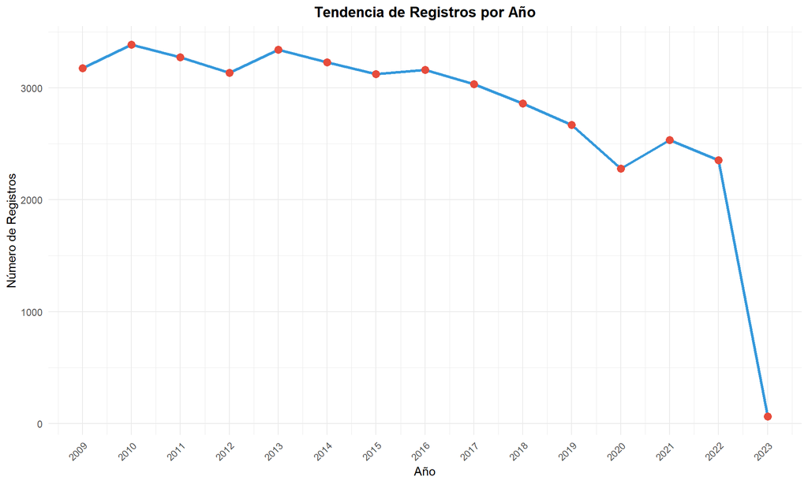

```r
if("AÑOREG" %in% names(datos)) {
  tendencia_anual <- datos %>%
    group_by(AÑOREG) %>%
    summarise(
      Total_Registros = n(),
      Edad_Promedio = mean(EDADM, na.rm = TRUE),
      Semanas_Promedio = mean(SEMGES, na.rm = TRUE)
    ) %>%
    filter(AÑOREG >= 2009 & AÑOREG <= 2023)

  # Gráfico de tendencia
  ggplot(tendencia_anual, aes(x = AÑOREG, y = Total_Registros)) +
    geom_line(color = "#3498db", size = 1.2) +
    geom_point(color = "#e74c3c", size = 3) +
    labs(
      title = "Tendencia de Registros por Año",
      x = "Año",
      y = "Número de Registros"
    ) +
    theme_minimal() +
    theme(
      plot.title = element_text(hjust = 0.5, face = "bold"),
      axis.text.x = element_text(angle = 45, hjust = 1)
    ) +
    scale_x_continuous(breaks = seq(2009, 2023, 1))
}
```

## 6.5 Resumen de Relaciones

```r
cat("\n")
```

```r
cat("========================================\n")
cat("RESUMEN DE RELACIONES ENTRE VARIABLES\n")
```

```
## RESUMEN DE RELACIONES ENTRE VARIABLES
```

```r
cat("========================================\n\n")
cat("**CORRELACIONES:**\n")
```

```
## **CORRELACIONES:**
```

```r
cat("--------------\n")
if(exists("correlaciones_significativas") && nrow(correlaciones_significativas) > 0) {
  cat("✓ Se encontraron", nrow(correlaciones_significativas),
      "correlaciones significativas (|r| > 0.3)\n")
  cat("  - Correlación más fuerte: r =",
      round(max(abs(correlaciones_significativas$Correlacion)), 3), "\n\n")
} else {
  cat("✗ No se encontraron correlaciones fuertes entre variables numéricas\n\n")
}
```

```
## ✓ Se encontraron 4 correlaciones significativas (|r| > 0.3)
##   - Correlación más fuerte: r = 0.846
```

```r
cat("**ASOCIACIONES CATEGÓRICAS:**\n")
```

```
## **ASOCIACIONES CATEGÓRICAS:**
```

```r
cat("-------------------------\n")
cat("✓ Se analizaron múltiples tablas de contingencia\n")
```

```
## ✓ Se analizaron múltiples tablas de contingencia
```

```r
cat("✓ Se aplicaron pruebas Chi-cuadrado para independencia\n\n")
```

```
## ✓ Se aplicaron pruebas Chi-cuadrado para independencia
```

```r
cat("**HALLAZGOS PRINCIPALES:**\n")
```

```
## **HALLAZGOS PRINCIPALES:**
```

```r
cat("----------------------\n")
cat("1. Relación entre edad de la madre y total de hijos tenidos\n")
```

```
## 1. Relación entre edad de la madre y total de hijos tenidos
```

```r
cat("2. Posible influencia del área geográfica en la asistencia recibida\n")
```

```
## 2. Posible influencia del área geográfica en la asistencia recibida
```

```r
cat("3. Tendencia temporal observable en el número de registros\n")
```

```
## 3. Tendencia temporal observable en el número de registros
```

```r
cat("4. Distribución relativamente equilibrada entre sexos\n")
```

```
## 4. Distribución relativamente equilibrada entre sexos
```